# Lab3

Author

Xinran Wang

## Running Code

```r
suppressPackageStartupMessages(library(datasauRus))
suppressPackageStartupMessages(library(ggplot2))
suppressPackageStartupMessages(library(tidyverse))
suppressPackageStartupMessages(library(leaflet))
```

### **1. Read in the data**

The data for this lab is available at https://github.com/USCbiostats/data-science-data/tree/master/02_met. There’s some additional information about the dataset, but the main file you’ll need to download is `met_all.gz`.

Once you’ve downloaded the file, you can read it into R with:

```r
idir <- "/Users/xinranwang/Documents/Course/25Fall/PM566/Data"
```

```r
met <- read.csv(paste0(idir, "/met_all.gz"))
```

### **2. Check the dimensions, headers, footers**

- How many columns, rows are there?

```r
dim(met)
```

```
[1] 2377343      30
```

```r
head(met)
```

```
  USAFID  WBAN year month day hour min  lat      lon elev wind.dir wind.dir.qc
1 690150 93121 2019     8   1    0  56 34.3 -116.166  696      220           5
2 690150 93121 2019     8   1    1  56 34.3 -116.166  696      230           5
3 690150 93121 2019     8   1    2  56 34.3 -116.166  696      230           5
4 690150 93121 2019     8   1    3  56 34.3 -116.166  696      210           5
5 690150 93121 2019     8   1    4  56 34.3 -116.166  696      120           5
6 690150 93121 2019     8   1    5  56 34.3 -116.166  696       NA           9
  wind.type.code wind.sp wind.sp.qc ceiling.ht ceiling.ht.qc ceiling.ht.method
1              N     5.7          5      22000             5                 9
2              N     8.2          5      22000             5                 9
3              N     6.7          5      22000             5                 9
4              N     5.1          5      22000             5                 9
5              N     2.1          5      22000             5                 9
6              C     0.0          5      22000             5                 9
  sky.cond vis.dist vis.dist.qc vis.var vis.var.qc temp temp.qc dew.point
1        N    16093           5       N          5 37.2       5      10.6
2        N    16093           5       N          5 35.6       5      10.6
3        N    16093           5       N          5 34.4       5       7.2
4        N    16093           5       N          5 33.3       5       5.0
5        N    16093           5       N          5 32.8       5       5.0
6        N    16093           5       N          5 31.1       5       5.6
  dew.point.qc atm.press atm.press.qc       rh
1            5    1009.9            5 19.88127
2            5    1010.3            5 21.76098
3            5    1010.6            5 18.48212
4            5    1011.6            5 16.88862
5            5    1012.7            5 17.38410
6            5    1012.7            5 20.01540
```

```r
tail(met)
```

```
        USAFID  WBAN year month day hour min    lat      lon elev wind.dir
2377338 726813 94195 2019     8  31   18  56 43.650 -116.633  741       NA
2377339 726813 94195 2019     8  31   19  56 43.650 -116.633  741       70
2377340 726813 94195 2019     8  31   20  56 43.650 -116.633  741       NA
2377341 726813 94195 2019     8  31   21  56 43.650 -116.633  741       10
2377342 726813 94195 2019     8  31   22  56 43.642 -116.636  741       10
2377343 726813 94195 2019     8  31   23  56 43.642 -116.636  741       40
        wind.dir.qc wind.type.code wind.sp wind.sp.qc ceiling.ht ceiling.ht.qc
2377338           9              C     0.0          5      22000             5
2377339           5              N     2.1          5      22000             5
2377340           9              C     0.0          5      22000             5
2377341           5              N     2.6          5      22000             5
2377342           1              N     2.1          1      22000             1
2377343           1              N     2.1          1      22000             1
        ceiling.ht.method sky.cond vis.dist vis.dist.qc vis.var vis.var.qc temp
2377338                 9        N    16093           5       N          5 30.0
2377339                 9        N    16093           5       N          5 32.2
2377340                 9        N    16093           5       N          5 33.3
2377341                 9        N    14484           5       N          5 35.0
2377342                 9        N    16093           1       9          9 34.4
2377343                 9        N    16093           1       9          9 34.4
        temp.qc dew.point dew.point.qc atm.press atm.press.qc       rh
2377338       5      11.7            5    1013.6            5 32.32509
2377339       5      12.2            5    1012.8            5 29.40686
2377340       5      12.2            5    1011.6            5 27.60422
2377341       5       9.4            5    1010.8            5 20.76325
2377342       1       9.4            1    1010.1            1 21.48631
2377343       1       9.4            1    1009.6            1 21.48631
```

### **3. Take a look at the variables.**

```r
str(met)
```

```
'data.frame':   2377343 obs. of  30 variables:
 $ USAFID           : int  690150 690150 690150 690150 690150 690150 690150 690150 690150 690150 ...
 $ WBAN             : int  93121 93121 93121 93121 93121 93121 93121 93121 93121 93121 ...
 $ year             : int  2019 2019 2019 2019 2019 2019 2019 2019 2019 2019 ...
 $ month            : int  8 8 8 8 8 8 8 8 8 8 ...
 $ day              : int  1 1 1 1 1 1 1 1 1 1 ...
 $ hour             : int  0 1 2 3 4 5 6 7 8 9 ...
 $ min              : int  56 56 56 56 56 56 56 56 56 56 ...
 $ lat              : num  34.3 34.3 34.3 34.3 34.3 34.3 34.3 34.3 34.3 34.3 ...
 $ lon              : num  -116 -116 -116 -116 -116 ...
 $ elev             : int  696 696 696 696 696 696 696 696 696 696 ...
 $ wind.dir         : int  220 230 230 210 120 NA 320 10 320 350 ...
 $ wind.dir.qc      : chr  "5" "5" "5" "5" ...
 $ wind.type.code   : chr  "N" "N" "N" "N" ...
 $ wind.sp          : num  5.7 8.2 6.7 5.1 2.1 0 1.5 2.1 2.6 1.5 ...
```

[output cut: 16 more lines]

### **4. Take a closer look at the key variables.**

```r
table(met$year)
```

```
   2019
2377343
```

```r
table(met$day)
```

```
    1     2     3     4     5     6     7     8     9    10    11    12    13
75975 75923 76915 76594 76332 76734 77677 77766 75366 75450 76187 75052 76906
   14    15    16    17    18    19    20    21    22    23    24    25    26
77852 76217 78015 78219 79191 76709 75527 75786 78312 77413 76965 76806 79114
   27    28    29    30    31
79789 77059 71712 74931 74849
```

```r
table(met$hour)
```

```
     0      1      2      3      4      5      6      7      8      9     10
 99434  93482  93770  96703 110504 112128 106235 101985 100310 102915 101880
    11     12     13     14     15     16     17     18     19     20     21
100470 103605  97004  96507  97635  94942  94184 100179  94604  94928  96070
    22     23
 94046  93823
```

```r
summary(met$temp)
```

```
   Min. 1st Qu.  Median    Mean 3rd Qu.    Max.    NA's
 -40.00   19.60   23.50   23.59   27.80   56.00   60089
```

```r
summary(met$elev)
```

```
   Min. 1st Qu.  Median    Mean 3rd Qu.    Max.
  -13.0   101.0   252.0   415.8   400.0  9999.0
```

```r
summary(met$wind.sp)
```

```
   Min. 1st Qu.  Median    Mean 3rd Qu.    Max.    NA's
   0.00    0.00    2.10    2.46    3.60   36.00   79693
```

It looks like the elevation variable has observations with 9999.0, which is probably an indicator for missing. We should take a deeper look at the data dictionary to confirm. The wind speed variable is OK but there are a lot of missing data.

After checking the data we should make the appropriate modifications. Replace elevations with 9999 as `NA`.

```r
met$elev[met$elev==9999.0] <- NA
summary(met$elev)
```

```
   Min. 1st Qu.  Median    Mean 3rd Qu.    Max.    NA's
    -13     101     252     413     400    4113     710
```

- At what elevation is the highest weather station?

We also have the issue of the minimum temperature being -40C, so we should remove those observations.

```r
#met <- met[temp>-40]
#met2 <- met[order(temp)]
met <- met %>% filter(temp > -40)
met2 <- met %>% arrange(temp)
head(met2)
```

```
  USAFID WBAN year month day hour min    lat    lon elev wind.dir wind.dir.qc
1 722817 3068 2019     8   1    0  56 38.767 -104.3 1838      190           5
2 722817 3068 2019     8   1    1  56 38.767 -104.3 1838      180           5
3 722817 3068 2019     8   3   11  56 38.767 -104.3 1838       NA           9
4 722817 3068 2019     8   3   12  56 38.767 -104.3 1838       NA           9
5 722817 3068 2019     8   6   21  56 38.767 -104.3 1838      280           5
6 722817 3068 2019     8   6   22  56 38.767 -104.3 1838      240           5
  wind.type.code wind.sp wind.sp.qc ceiling.ht ceiling.ht.qc ceiling.ht.method
1              N     7.2          5         NA             9                 9
2              N     7.7          5         NA             9                 9
3              C     0.0          5         NA             9                 9
4              C     0.0          5         NA             9                 9
5              N     2.6          5         NA             9                 9
6              N     7.7          5         NA             9                 9
  sky.cond vis.dist vis.dist.qc vis.var vis.var.qc  temp temp.qc dew.point
1        N       NA           9       N          5 -17.2       5        NA
2        N       NA           9       N          5 -17.2       5        NA
3        N       NA           9       N          5 -17.2       5        NA
4        N       NA           9       N          5 -17.2       5        NA
5        N       NA           9       N          5 -17.2       5        NA
6        N       NA           9       N          5 -17.2       5        NA
  dew.point.qc atm.press atm.press.qc rh
1            9        NA            9 NA
2            9        NA            9 NA
3            9        NA            9 NA
4            9        NA            9 NA
5            9        NA            9 NA
6            9        NA            9 NA
```

We again notice that there is a -17.2C temperature reading that seems suspicious.

### **5. Check the data against an external data source.**

We should check the suspicious temperature value (where is it located?) and validate that the range of elevations make sense (-13 m to 4113 m).

Google is your friend here.

Fix any problems that arise in your checks.

```r
#met <- met[temp>-15]
#met2 <- met[order(temp)]
met <- met %>% filter(temp > -15)
met2 <- met %>% arrange(temp)
head(met2)
```

```
  USAFID  WBAN year month day hour min    lat      lon elev wind.dir
1 726764 94163 2019     8  27   11  50 44.683 -111.116 2025       NA
2 726764 94163 2019     8  27   12  10 44.683 -111.116 2025       NA
3 726764 94163 2019     8  27   12  30 44.683 -111.116 2025       NA
4 726764 94163 2019     8  27   12  50 44.683 -111.116 2025       NA
5 720411   137 2019     8  18   12  35 36.422 -105.290 2554       NA
6 726764 94163 2019     8  26   12  30 44.683 -111.116 2025       NA
  wind.dir.qc wind.type.code wind.sp wind.sp.qc ceiling.ht ceiling.ht.qc
1           9              C       0          5      22000             5
2           9              C       0          5      22000             5
3           9              C       0          5      22000             5
4           9              C       0          5      22000             5
5           9              C       0          5      22000             5
6           9              C       0          5      22000             5
  ceiling.ht.method sky.cond vis.dist vis.dist.qc vis.var vis.var.qc temp
1                 9        N    16093           5       N          5 -3.0
2                 9        N    16093           5       N          5 -3.0
3                 9        N    16093           5       N          5 -3.0
4                 9        N    16093           5       N          5 -3.0
5                 9        N    16093           5       N          5 -2.4
6                 9        N    16093           5       N          5 -2.0
  temp.qc dew.point dew.point.qc atm.press atm.press.qc       rh
1       C      -5.0            C        NA            9 86.26537
2       5      -4.0            5        NA            9 92.91083
3       5      -4.0            5        NA            9 92.91083
4       C      -4.0            C        NA            9 92.91083
5       5      -3.7            5        NA            9 90.91475
6       5      -3.0            5        NA            9 92.96690
```

- Summarize that we removed temperatures colder than -15C. The new dataset has a minimum temp of -3C, which is reasonable.

### **6. Calculate summary statistics**

Remember to keep the initial question in mind. We want to pick out the weather station with maximum elevation and examine its windspeed and temperature.

Some ideas: select the weather station with maximum elevation; look at the correlation between temperature and wind speed; look at the correlation between temperature and wind speed with hour and day of the month.

```r
#elev <- met[elev==max(elev), ]
elev <- met %>% filter(elev == max(elev, na.rm = TRUE))
summary(elev)
```

```
     USAFID            WBAN          year          month        day
 Min.   :720385   Min.   :419   Min.   :2019   Min.   :8   Min.   : 1.0
 1st Qu.:720385   1st Qu.:419   1st Qu.:2019   1st Qu.:8   1st Qu.: 8.0
 Median :720385   Median :419   Median :2019   Median :8   Median :16.0
 Mean   :720385   Mean   :419   Mean   :2019   Mean   :8   Mean   :16.1
 3rd Qu.:720385   3rd Qu.:419   3rd Qu.:2019   3rd Qu.:8   3rd Qu.:24.0
 Max.   :720385   Max.   :419   Max.   :2019   Max.   :8   Max.   :31.0

      hour            min             lat            lon              elev
 Min.   : 0.00   Min.   : 6.00   Min.   :39.8   Min.   :-105.8   Min.   :4113
 1st Qu.: 6.00   1st Qu.:13.00   1st Qu.:39.8   1st Qu.:-105.8   1st Qu.:4113
 Median :12.00   Median :36.00   Median :39.8   Median :-105.8   Median :4113
 Mean   :11.66   Mean   :34.38   Mean   :39.8   Mean   :-105.8   Mean   :4113
 3rd Qu.:18.00   3rd Qu.:53.00   3rd Qu.:39.8   3rd Qu.:-105.8   3rd Qu.:4113
 Max.   :23.00   Max.   :59.00   Max.   :39.8   Max.   :-105.8   Max.   :4113

    wind.dir     wind.dir.qc        wind.type.code        wind.sp
 Min.   : 10.0   Length:2117        Length:2117        Min.   : 0.000
 1st Qu.:250.0   Class :character   Class :character   1st Qu.: 4.100
 Median :300.0   Mode  :character   Mode  :character   Median : 6.700
 Mean   :261.5                                         Mean   : 7.245
 3rd Qu.:310.0                                         3rd Qu.: 9.800
 Max.   :360.0                                         Max.   :21.100
 NA's   :237                                           NA's   :168
  wind.sp.qc          ceiling.ht    ceiling.ht.qc   ceiling.ht.method
 Length:2117        Min.   :   30   Min.   :5.000   Length:2117
 Class :character   1st Qu.: 2591   1st Qu.:5.000   Class :character
 Mode  :character   Median :22000   Median :5.000   Mode  :character
                    Mean   :15145   Mean   :5.008
                    3rd Qu.:22000   3rd Qu.:5.000
                    Max.   :22000   Max.   :9.000
                    NA's   :4
   sky.cond            vis.dist     vis.dist.qc          vis.var
 Length:2117        Min.   :    0   Length:2117        Length:2117
 Class :character   1st Qu.:16093   Class :character   Class :character
 Mode  :character   Median :16093   Mode  :character   Mode  :character
                    Mean   :15913
                    3rd Qu.:16093
                    Max.   :16093
                    NA's   :683
  vis.var.qc             temp         temp.qc            dew.point
 Length:2117        Min.   : 1.00   Length:2117        Min.   :-6.0000
 Class :character   1st Qu.: 6.00   Class :character   1st Qu.: 0.0000
 Mode  :character   Median : 8.00   Mode  :character   Median : 0.0000
                    Mean   : 8.13                      Mean   : 0.8729
                    3rd Qu.:10.00                      3rd Qu.: 2.0000
                    Max.   :15.00                      Max.   : 7.0000

 dew.point.qc         atm.press     atm.press.qc       rh
 Length:2117        Min.   : NA    Min.   :9     Min.   :53.63
 Class :character   1st Qu.: NA    1st Qu.:9     1st Qu.:58.10
 Mode  :character   Median : NA    Median :9     Median :61.39
                    Mean   :NaN    Mean   :9     Mean   :60.62
                    3rd Qu.: NA    3rd Qu.:9     3rd Qu.:61.85
                    Max.   : NA    Max.   :9     Max.   :70.01
                    NA's   :2117
```

```r
cor(elev$temp, elev$wind.sp, use="complete")
```

```
[1] -0.09373843
```

```r
cor(elev$temp, elev$hour, use="complete")
```

```
[1] 0.4397261
```

```r
cor(elev$wind.sp, elev$day, use="complete")
```

```
[1] 0.3643079
```

```r
cor(elev$wind.sp, elev$hour, use="complete")
```

```
[1] 0.08807315
```

```r
cor(elev$temp, elev$day, use="complete")
```

```
[1] -0.003857766
```

### **7. Exploratory graphs**

We should look at the distributions of all of the key variables to make sure there are no remaining issues with the data.

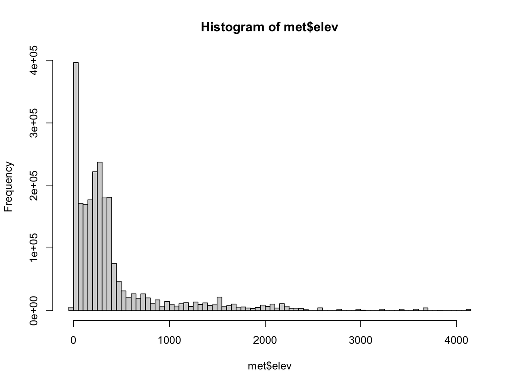

```r
hist(met$elev, breaks=100)
```

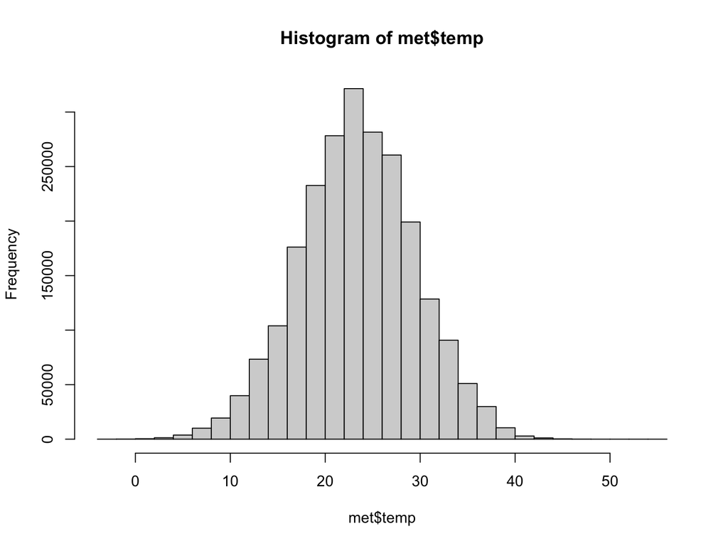

```r
hist(met$temp)
```

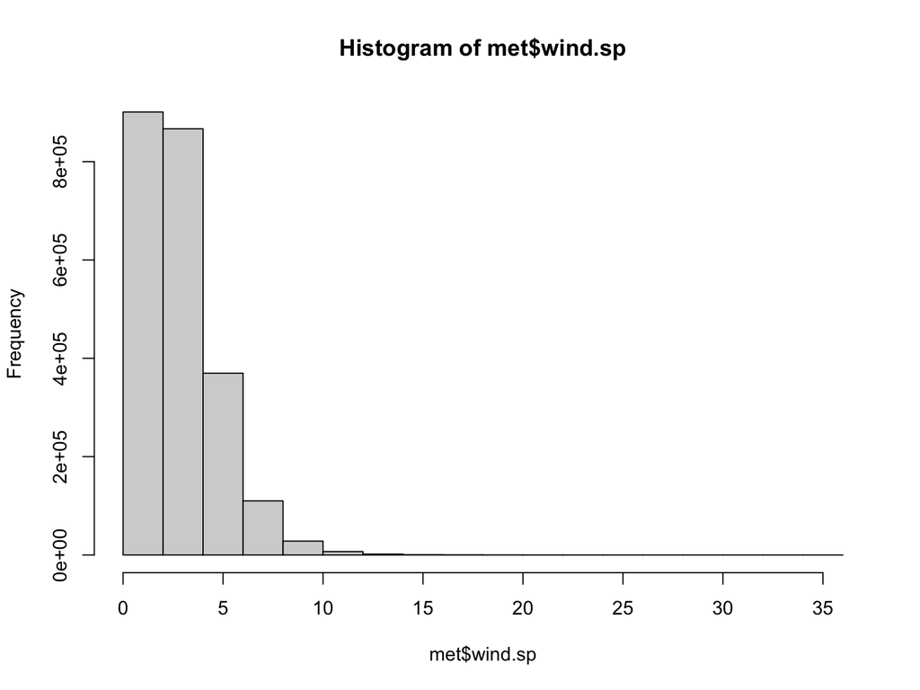

```r
hist(met$wind.sp)
```

One thing we should consider for later analyses is to log transform wind speed and elevation as they are very skewed.

Look at where the weather station with highest elevation is located.

```r
leaflet(elev) %>%
  addProviderTiles('OpenStreetMap') %>%
  addCircles(lat=~lat,lng=~lon, opacity=1, fillOpacity=1, radius=100)
```

[interactive chart not shown]

Look at the time series of temperature and wind speed at this location. For this we will need to create a date-time variable for the x-axis.

```r
library(lubridate)
elev$date <- with(elev, ymd_h(paste(year, month, day, hour, sep= ' ')))
summary(elev$date)
```

```
                      Min.                    1st Qu.
"2019-08-01 00:00:00.0000" "2019-08-08 11:00:00.0000"
                    Median                       Mean
"2019-08-16 22:00:00.0000" "2019-08-16 14:09:56.8823"
                   3rd Qu.                       Max.
"2019-08-24 11:00:00.0000" "2019-08-31 22:00:00.0000"
```

```r
#elev <- elev[order(date)]
elev <- elev %>% arrange(date)
head(elev)
```

```
  USAFID WBAN year month day hour min  lat      lon elev wind.dir wind.dir.qc
1 720385  419 2019     8   1    0  36 39.8 -105.766 4113      170           5
2 720385  419 2019     8   1    0  54 39.8 -105.766 4113      100           5
3 720385  419 2019     8   1    1  12 39.8 -105.766 4113       90           5
4 720385  419 2019     8   1    1  35 39.8 -105.766 4113      110           5
5 720385  419 2019     8   1    1  53 39.8 -105.766 4113      120           5
6 720385  419 2019     8   1    2  12 39.8 -105.766 4113      120           5
  wind.type.code wind.sp wind.sp.qc ceiling.ht ceiling.ht.qc ceiling.ht.method
1              N     8.8          5       1372             5                 M
2              N     2.6          5       1372             5                 M
3              N     3.1          5       1981             5                 M
4              N     4.1          5       2134             5                 M
5              N     4.6          5       2134             5                 M
6              N     6.2          5      22000             5                 9
  sky.cond vis.dist vis.dist.qc vis.var vis.var.qc temp temp.qc dew.point
1        N       NA           9       N          5    9       5         1
2        N       NA           9       N          5    9       5         1
3        N       NA           9       N          5    9       5         2
4        N       NA           9       N          5    9       5         2
5        N       NA           9       N          5    9       5         2
6        N       NA           9       N          5    9       5         2
  dew.point.qc atm.press atm.press.qc       rh                date
1            5        NA            9 57.61039 2019-08-01 00:00:00
2            5        NA            9 57.61039 2019-08-01 00:00:00
3            5        NA            9 61.85243 2019-08-01 01:00:00
4            5        NA            9 61.85243 2019-08-01 01:00:00
5            5        NA            9 61.85243 2019-08-01 01:00:00
6            5        NA            9 61.85243 2019-08-01 02:00:00
```

With the date-time variable we can plot the time series of temperature and wind speed.

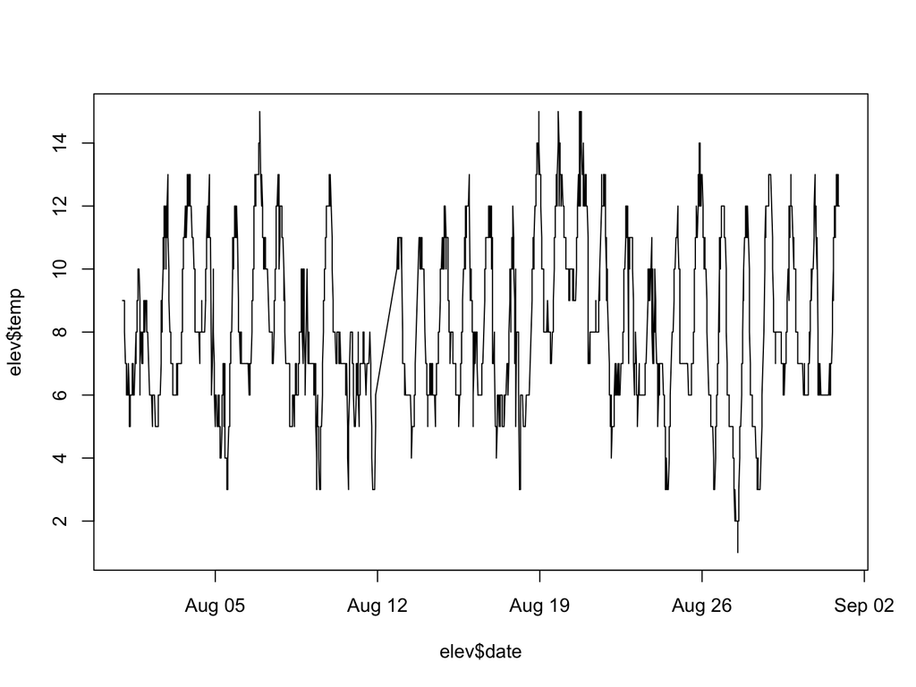

```r
plot(elev$date, elev$temp, type='l')
```

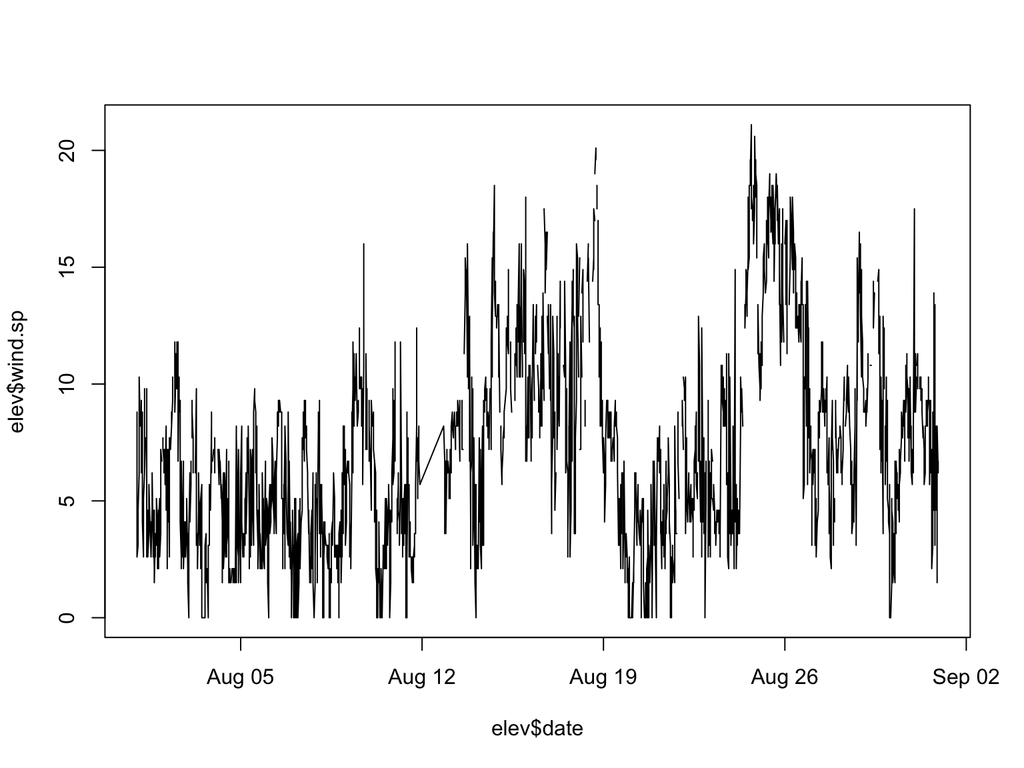

```r
plot(elev$date, elev$wind.sp, type='l')
```

- Summarize any trends that you see in these time series plots.

  **Summary.** Overall, temperature fluctuates between 1°C and 15°C, reflecting daily variation. On August 11, the maximum temperature is relatively low at 8°C, compared to the surrounding days (see table below)

  **Summary.** Wind speed is relativly high in 8/9, 8/13-8/18, 8/24-8/26, and 8/31.

```r
library(knitr)
kable(elev %>% group_by(year, month, day) %>% summarize(min_temp = min(temp, na.rm = TRUE), max_temp=max(temp, na.rm = TRUE)))
```

| year | month | day | min_temp | max_temp |
| --- | --- | --- | --- | --- |
| 2019 | 8 | 1 | 5 | 10 |
| 2019 | 8 | 2 | 5 | 13 |
| 2019 | 8 | 3 | 6 | 13 |
| 2019 | 8 | 4 | 6 | 13 |
| 2019 | 8 | 5 | 3 | 12 |
| 2019 | 8 | 6 | 6 | 15 |
| 2019 | 8 | 7 | 7 | 13 |
| 2019 | 8 | 8 | 5 | 10 |
| 2019 | 8 | 9 | 3 | 13 |
| 2019 | 8 | 10 | 3 | 12 |
| 2019 | 8 | 11 | 3 | 8 |
| 2019 | 8 | 12 | 10 | 11 |
| 2019 | 8 | 13 | 4 | 11 |
| 2019 | 8 | 14 | 5 | 12 |
| 2019 | 8 | 15 | 5 | 13 |
| 2019 | 8 | 16 | 5 | 12 |
| 2019 | 8 | 17 | 4 | 12 |
| 2019 | 8 | 18 | 3 | 15 |
| 2019 | 8 | 19 | 7 | 15 |
| 2019 | 8 | 20 | 9 | 15 |
| 2019 | 8 | 21 | 7 | 13 |
| 2019 | 8 | 22 | 4 | 12 |
| 2019 | 8 | 23 | 5 | 11 |
| 2019 | 8 | 24 | 3 | 12 |
| 2019 | 8 | 25 | 6 | 14 |
| 2019 | 8 | 26 | 3 | 13 |
| 2019 | 8 | 27 | 1 | 12 |
| 2019 | 8 | 28 | 3 | 13 |
| 2019 | 8 | 29 | 6 | 13 |
| 2019 | 8 | 30 | 6 | 13 |
| 2019 | 8 | 31 | 6 | 13 |

```r
kable(elev %>% group_by(year, month, day) %>% summarize(min_wind.sp = min(wind.sp, na.rm = TRUE), max_wind.sp=max(wind.sp, na.rm = TRUE)))
```

| year | month | day | min_wind.sp | max_wind.sp |
| --- | --- | --- | --- | --- |
| 2019 | 8 | 1 | 1.5 | 10.3 |
| 2019 | 8 | 2 | 1.5 | 11.8 |
| 2019 | 8 | 3 | 0.0 | 9.8 |
| 2019 | 8 | 4 | 1.5 | 8.8 |
| 2019 | 8 | 5 | 1.5 | 9.8 |
| 2019 | 8 | 6 | 0.0 | 9.3 |
| 2019 | 8 | 7 | 0.0 | 9.3 |
| 2019 | 8 | 8 | 0.0 | 9.3 |
| 2019 | 8 | 9 | 2.1 | 16.0 |
| 2019 | 8 | 10 | 0.0 | 11.8 |
| 2019 | 8 | 11 | 0.0 | 12.4 |
| 2019 | 8 | 12 | 3.6 | 8.2 |
| 2019 | 8 | 13 | 2.1 | 16.0 |
| 2019 | 8 | 14 | 0.0 | 18.5 |
| 2019 | 8 | 15 | 5.7 | 16.0 |
| 2019 | 8 | 16 | 6.7 | 18.0 |
| 2019 | 8 | 17 | 2.6 | 16.0 |
| 2019 | 8 | 18 | 7.2 | 20.1 |
| 2019 | 8 | 19 | 0.0 | 9.3 |
| 2019 | 8 | 20 | 0.0 | 6.7 |
| 2019 | 8 | 21 | 0.0 | 11.3 |
| 2019 | 8 | 22 | 0.0 | 12.9 |
| 2019 | 8 | 23 | 2.1 | 11.3 |
| 2019 | 8 | 24 | 2.1 | 21.1 |
| 2019 | 8 | 25 | 9.3 | 19.0 |
| 2019 | 8 | 26 | 5.1 | 18.0 |
| 2019 | 8 | 27 | 2.1 | 11.8 |
| 2019 | 8 | 28 | 3.1 | 16.5 |
| 2019 | 8 | 29 | 3.6 | 14.9 |
| 2019 | 8 | 30 | 0.0 | 11.3 |
| 2019 | 8 | 31 | 1.5 | 17.5 |

### **8. Ask questions**

By now, you might have some specific questions about how the data was gathered and what some of the different variables and values mean. Alternatively, maybe you have an idea for how some of the variable should be related and you want to explore that relationship. In a real-world analysis, these questions could potentially be answered by a collaborator, who may have been part of the team that collected the data. What questions do you have about the data?

If you haven’t already, now would be a good time to look at the accompanying [data dictionary](https://github.com/USCbiostats/data-science-data/blob/master/02_met/met-datadictionary.pdf) for this dataset and see if it can answer any of your questions. If you have questions about the nature of the dataset and how it was gathered, this might be able to help.

For questions about variables in the dataset or relationships between them, try making some more exploratory plots. Do you see the patterns you would expect? There are many different types of summaries and visualization strategies that we have not discussed, but which could provide interesting perspectives on the data.

Some other useful plotting functions include: - `pairs` for making all pairwise scatter plots in a dataset with >2 dimensions. - `heatmap` and/or `corrplot` (from the `corrplot` package) for visualizing matrices in general or correlation matrices in particular. - `image` a low-level matrix visualization function - `barplot`, especially with `table`, for visualizing frequencies of categorical variables.